# Lab5: Pruebas de hipótesis

Jorge de la Vega

11/03/2022

## Pruebas de hipótesis

### Mediciones de primer y segundo hijo.

Frets (1921) tomó medidas antropométricas del primer y segundo hijo en una muestra de 25 familias. Las variables que consideró son las siguientes:

- `l1` y `l2`: longitud de la cabeza del primer y segundo hijo, respectivamente.
- `b1` y `b2`: amplitud de la cabeza del primer y segundo hijo, respectivamente.

Los datos están en el paquete `boot` en R:

```r
library(boot)
data(frets)
str(frets)
```

```
'data.frame':   25 obs. of  4 variables:
 $ l1: num  191 195 181 183 176 208 189 197 188 192 ...
 $ b1: num  155 149 148 153 144 157 150 159 152 150 ...
 $ l2: num  179 201 185 188 171 192 190 189 197 187 ...
 $ b2: num  145 152 149 149 142 152 149 152 159 151 ...
```

Visualiza:

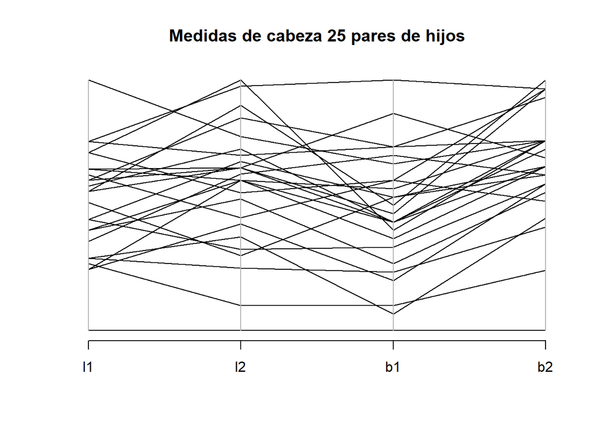

```r
library(MASS)
parcoord(frets[,c(1,3,2,4)], main = "Medidas de cabeza 25 pares de hijos")
```

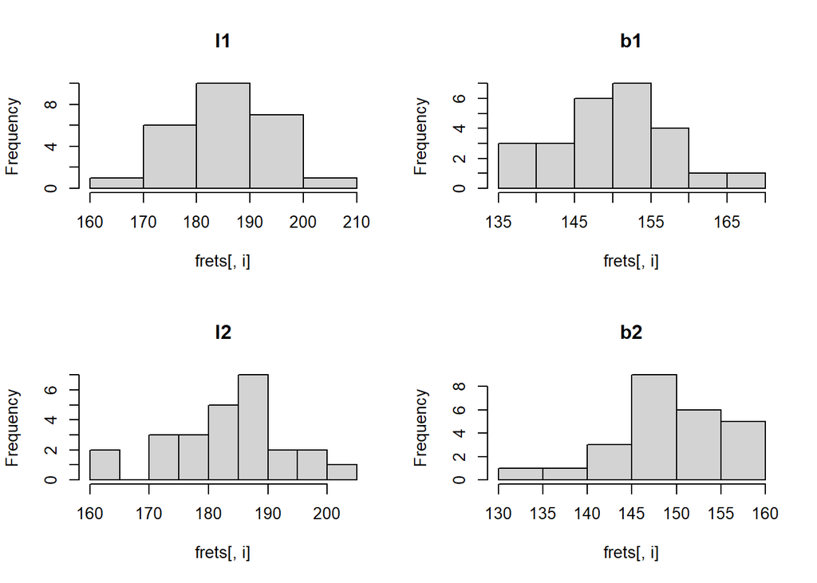

```r
par(mfrow=c(2,2))
for(i in 1:4) hist(frets[,i],main = names(frets)[i])
```

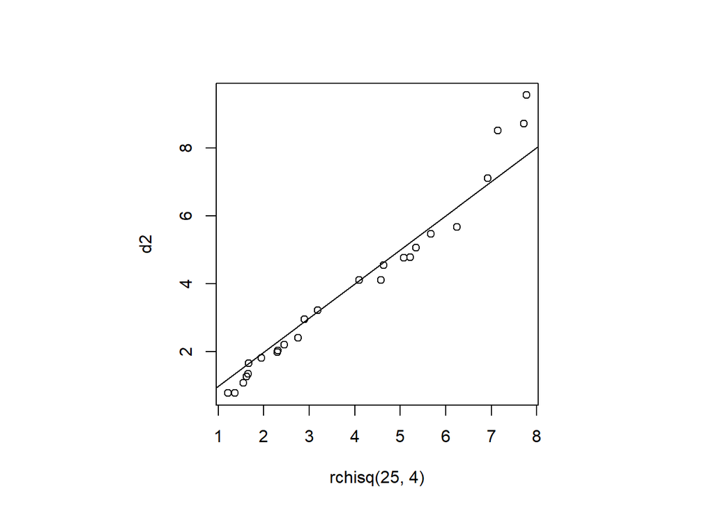

```r
# Gráfica para verificar normalidad multivariada
par(mfrow=c(1,1), pty="s")
set.seed(1)
qqplot(rchisq(25,4),mahalanobis(frets, center = colMeans(frets), cov = var(frets)),ylab="d2")
abline(a=0,b=1)
```

Para este ejercicio se puede hacer una prueba de hipótesis para cada media, cada varianza y cada covarianza. Con 4 variables se tienen 14 parámetros a probar y hay $2^{14} = 16,384$ posibles subconjuntos a formar combinando estos parámetros.

Los estimadores del vector de media y de matriz de varianzas y covarianzas son:

```r
(n <- nrow(frets))
```

```
[1] 25
```

```r
(xbar <- colMeans(frets)) # vector de medias
```

```
    l1     b1     l2     b2
185.72 151.12 183.84 149.24
```

```r
(S <- var(frets))  # estimador insesgado
```

```
         l1       b1        l2       b2
l1 95.29333 52.86833  69.66167 46.11167
b1 52.86833 54.36000  51.31167 35.05333
l2 69.66167 51.31167 100.80667 56.54000
b2 46.11167 35.05333  56.54000 45.02333
```

```r
sum(diag(S))       # varianza total
```

```
[1] 295.4833
```

```r
det(S)             # varianza generalizada
```

```
[1] 1207109
```

Supongamos momentáneamente que `l1` y `l2` son normales independientes y que cada una tiene varianza 100 (no lo son, pero supongamos). Se desea probar la hipótesis de que ambas medias son 182:

$$H_1: l1 \sim N(182,100),\qquad H_2: l2 \sim N(182,100)$$

- ¿Cuál es la prueba univariada usual para cada hipótesis?
- La hipótesis bivariada considera que se dan las dos hipótesis simultáneamente: $H_3: H_1 \cap H_2$, que será cierta si y sólo si ambas hipótesis son ciertas. Hay varias formas de probar $H_3$:
1. Acepta $H_3$ si y sól si se aceptan $H_1$ y $H_2$ univariadamente.
2. Si $H_1$ y $H_2$ son verdaderas, $z_3 = (z_1+z_2)/\sqrt{2} \sim N(0,1)$. Como $z_3 = 1.965757$, el p-value es 0.0493, por lo que se rechaza $H_3$. Notar que en este caso ¡la hipótesis nula multivariada se rechaza a pesar de que cada prueba en lo individual no fue significativa.
3. Si $H_1$ y $H_2$ son verdaderas, entonces $z_4 = z_1^2+z_2^2 \sim \chi^2_2$. En este caso $z_4 = 4.306 y el p-value es 0.1161, por lo que la prueba no es significativa, por lo que no se rechaza $H_3$.
4. Otra opción es considerar la correlación entre $z_1$ y $z_2$ (es decir, que no sean independientes como supusimos), lo que implica considerar la distancia de Mahalanobis, y por lo tanto una región de aceptación elíptica.

Las pruebas anteriores, según la estadística de prueba que se utilice, tienen regiones de rechazo de diferente formageométrica: rectangular, linear, circular y elíptica. La forma de la región de no rechazo puede llevar a resultados contradictorios.

## Pruebas basadas en la razón de verosimilitud.

Hay tres casos a considerar en el caso de normal multivariada.

- Caso A: $H_0: \mu = \mu_0$ con $\Sigma_0$ conocida
- Caso B: $H_0: \mu = \mu_0$ con $\Sigma$ desconocida
- Caso C: $H_0: \Sigma = \Sigma_0$ con $\mu$ desconocida

### Caso A

Hay más, pero estos son muy comunes. Para el ejemplo que estamos considerando, estamos en el caso A. La prueba de versimilitud nos da en este caso:

```r
mu0 <- c(182,182)
S0 <- 100* diag(2)
(LRT <- as.numeric(n*((xbar[c(1,3)]-mu0) %*% solve(S0) %*% (xbar[c(1,3)]-mu0))))
```

```
[1] 4.306
```

```r
pchisq(LRT,2,lower.tail = F) #p-value de la distribución chi^2 con 2 grados de libertad
```

```
[1] 0.1161352
```

que es lo mismo que la región elíptica

$$(185.72 -\mu\_1)\^2 + (183.84-\mu\_3)\^2 \< 23.96$$

```r
library(ellipse)
```

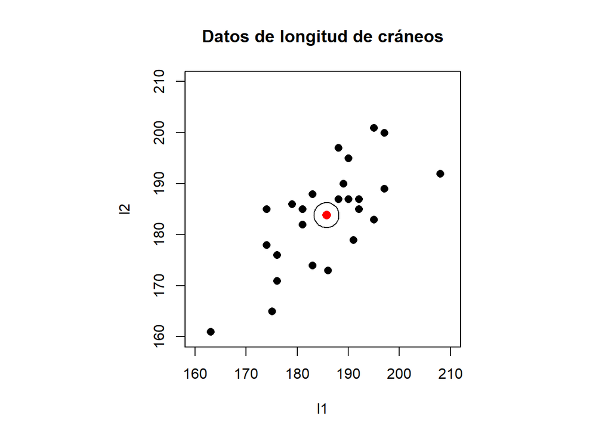

```r
par(pty = "s")
plot(frets[,c(1,3)], pch = 16, cex = 1.2,
     main= "Datos de longitud de cráneos",
     ylim = c(160,210), xlim = c(160,210))
lines(ellipse(0, centre = xbar[c(1,3)], t = sqrt(qchisq(0.95,2))))
points(xbar[1],xbar[3], col = "red", cex = 1.3, pch = 16)
```

### Caso B

En este caso, tenemos $(l1,l2) \sim N_2(\mu_0,\Sigma)$ con $\mu_0 = [182,182]'$ y $\Sigma$ debe estimarse. La estadística de prueba sale de la $\Lambda$ de Wilks y se puede calcular como la función de la $T^2$ de Hotelling.

Cálculo opción 1: directo

```r
p <- 2
X <- as.matrix(frets[,c(1,3)], ncol = 2) # subconjunto de datos
S0 <- (t(X - mu0) %*% (X - mu0))/n  # Bajo H0
S1 <- (n-1)/n*S[c(1,3),c(1,3)]    # Subconjunto de la Sn, de máxima verosimilitud
(T2 <- (n-1)*(det(S0)/det(S1)-1))# Estadística de prueba
```

```
[1] 4.018065
```

```r
(F0 <- T2*(n-p)/(p*(n-1)))
```

```
[1] 1.925323
```

```r
1-pf(F0,p,n-p)
```

```
[1] 0.1686129
```

Cálculo opción 2

```r
p <- 2
(T2 <- n*mahalanobis(xbar[c(1,3)], center = mu0, cov = S[c(1,3),c(1,3)]))
```

```
[1] 4.018065
```

```r
(F0 <- T2*(n-p)/(p*(n-1)))
```

```
[1] 1.925323
```

```r
1-pf(F0,p,n-p)
```

```
[1] 0.1686129
```

#### Ejemplo 5.2

Los siguientes datos corresponden a la transpiración de 20 mujeres sanas:

- $V_1=$ tasa de duración
- $V_2=$ contenido de sodio
- $V_3=$ contenido de potasio

Se quiere probar la hipótesis $H_0: \mu = [4,50,10]'$ vs $H_1: \mu \neq [4,5,10]'$ a un nivel de significancia del 10%. Bajo el supuesto de normalidad

```r
Z <- read.table("https://raw.githubusercontent.com/jvega68/EA3/master/datos/J%26W/T5-1.DAT",
                sep = "",header = FALSE)
xbar <- colMeans(Z)
S <- var(Z)
p <- ncol(Z); n <- nrow(Z)
mu0 <- c(4,50,10)
```

Calculamos la $T^2$ y el p-value de la prueba

```r
(T2 <- n*mahalanobis(xbar, center = mu0, cov = S))
```

```
[1] 9.738773
```

```r
(F0 <- (n-p)/(p*(n-1))*T2)
```

```
[1] 2.904546
```

```r
1-pf(F0,p,n-p)
```

```
[1] 0.06492834
```

### Caso C

Esta es una prueba para varianzas. La estdítica de prueba es de la forma:

$$-2\log\lambda = n \cdot tr(\Sigma\_0\^{-1}S) - n
\log(\Sigma\_0\^{-1}S) -np$$

Sea $a$ el promedio y $g$ la media geométrica de de los valores propios de $\Sigma_0^{-1}S$. De tal manera que $tr(\Sigma_0^{-1}S)= pa$ y $|\Sigma_0^{-1}S| = g^p$ Entonces la prueba se puede escribir como:

$$-2\log\lambda = np(a-\log(g)-1)$$

La estadística no tiene una distribución simple. Entonces conviene usar la distribución asintótica de $-2\log\lambda$ que es $\chi^2_{(p(p+1)/2)}$

En los datos de Frets

```r
n <- 25; p <- 2
S0 <- matrix(c(100, 50, 50, 100 ), nrow = 2) # hipótesis a evaluar
(lambdas <- eigen(solve(S0)%*%S1)$values)
```

```
[1] 1.0751163 0.5432943
```

```r
a <- mean(lambdas)
g <- exp(mean(log(lambdas)))
F0 <- n*p*(a-log(g)-1) # Estadística
1-pchisq(F0,p*(p+1)/2) # No se rechaza la hipótesis.
```

```
[1] 0.2722263
```

## Intervalos de confianza.

### Ejemplo 1.

Las calificaciones obtenidas por 87 estudiantes de colegios para tres materias están en las siguientes variables:

- $X_1$ = ciencias sociales e historia
- $X_2$ = verbal
- $X_3$ = ciencia

```r
X <- read.table("https://raw.githubusercontent.com/jvega68/EA3/master/datos/J%26W/T5-2.DAT",
           col.names = c("X1","X2","X3"))

#dimensiones
(n <- nrow(X))
```

```
[1] 87
```

```r
(p <- ncol(X))
```

```
[1] 3
```

```r
# Estimadores máximo verosímiles
(xbar <- colMeans(X))
```

```
       X1        X2        X3
526.58621  54.68966  25.12644
```

```r
(S <- var(X))
```

```
          X1        X2        X3
X1 5808.0593 597.83520 222.02967
X2  597.8352 126.05373  23.38853
X3  222.0297  23.38853  23.11173
```

```r
(Sn <- (n-1)/n*S)
```

```
          X1       X2        X3
X1 5741.3000 590.9635 219.47761
X2  590.9635 124.6048  23.11970
X3  219.4776  23.1197  22.84608
```

¿Estos datos son normales?

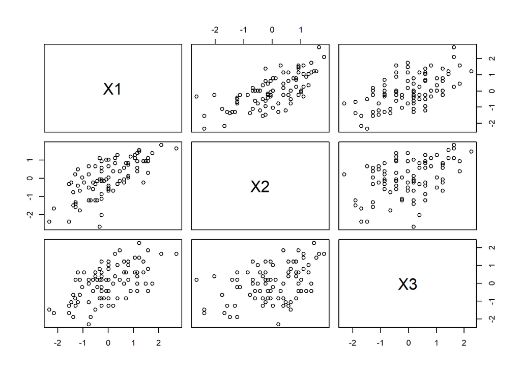

```r
Z <- scale(X)  # variables estandarizadas
pairs(Z)
```

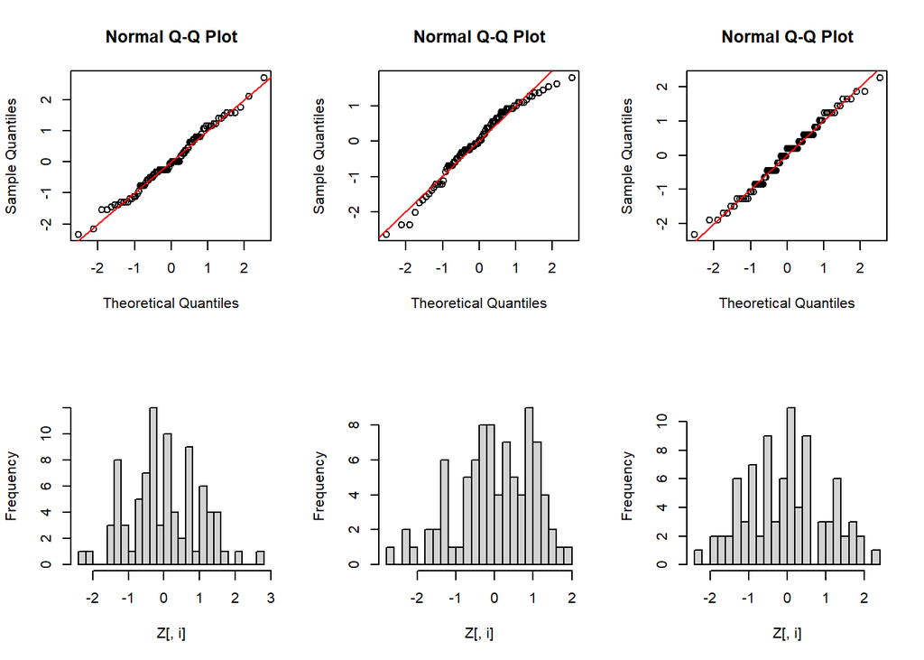

```r
par(mfcol=c(2,p))
for(i in 1:p){
    qqnorm(Z[,i])
    abline(a=0,b=1,col="red")
    hist(Z[,i],breaks=20, main="")
}
```

```r
for(i in 1:p)print(ks.test(Z[,i],"pnorm"))
```

```
    One-sample Kolmogorov-Smirnov test

data:  Z[, i]
D = 0.095535, p-value = 0.4051
alternative hypothesis: two-sided
```

```
    One-sample Kolmogorov-Smirnov test

data:  Z[, i]
D = 0.080775, p-value = 0.6214
alternative hypothesis: two-sided
```

```
    One-sample Kolmogorov-Smirnov test

data:  Z[, i]
D = 0.077842, p-value = 0.6675
alternative hypothesis: two-sided
```

1. Obtener los intervalos de confianza **simultáneos** del 95% para $\mu_1$, $\mu_2$ y $\mu_3$

```r
c1 <- p*(n-1)/(n-p)*qf(.05,p,n-p,lower.tail = F)
for(i in 1:3)print(xbar[i] + c(-1,1)*sqrt(c1*diag(S)[i]/n ))
```

```
[1] 502.9994 550.1730
[1] 51.21484 58.16447
[1] 23.63855 26.61432
```

Usualmente, los intervalos simultáneos basados en la $T^2$ de Hotelling tienden a ser más anchos que los intervalos marginales porque toman en cuenta todas las posibles dependencias entre las variables.

Para las diferencias de las medias:

```r
int.simul <- function(alfa,n,xbar,S,a){
  p <- length(xbar)
  c1 <- p*(n-1)/(n-p)*qf(alfa,p,n-p,lower.tail = F)
  (as.numeric(t(a)%*%xbar)) + c(-1,1)*sqrt(c1* as.numeric(t(a)%*%S%*%a)/n)
}

int.simul(alfa = 0.05, n = n, xbar = xbar, S = S, a=c(1,-1,0))
```

```
[1] 450.5920 493.2011
```

```r
int.simul(alfa = 0.05, n = n, xbar = xbar, S = S, a=c(0,1,-1))
```

```
[1] 26.43153 32.69491
```

```r
int.simul(alfa = 0.05, n = n, xbar = xbar, S = S, a=c(1,0,-1) )
```

```
[1] 478.7438 524.1758
```

2. Obtener un intervalo de confianza de 95% para el promedio de las tres calificaciones de cada estudiante.

```r
a <- c(1/3,1/3,1/3)  #ponderador para la media de los examenes
int.simul(alfa = 0.05, n = n, xbar = xbar, S = S, a=rep(1/3,3))
```

```
[1] 193.1145 211.1537
```

3. Obtener los intervalos marginales uno a la vez al 95%

```r
c2 <- qt(.05/2,n-1,lower.tail = F)
for(i in 1:3) print(xbar[i] + c(-1,1)*c2*sqrt(diag(S)[i]/n))
```

```
[1] 510.3435 542.8289
[1] 52.29678 57.08253
[1] 24.10183 26.15105
```

4. Obtener los intervalos Bonferronizados para cada media.

```r
c3 <- qt(.05/(2*p), n-1, lower.tail = F)
for(i in 1:3) print(xbar[i] + c(-1,1)*c3*sqrt(diag(S)[i]/n))
```

```
[1] 506.6359 546.5365
[1] 51.75057 57.62874
[1] 23.86794 26.38493
```

5. Graficar las regiones de confianza y los intervalos simultáneos, marginales y bonferronizados para $\mu_1$ y $\mu_2$.

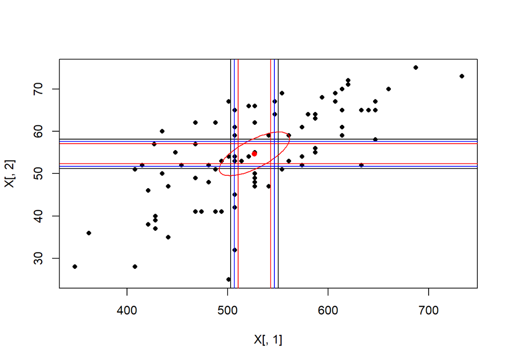

```r
library(ellipse)

plot(X[,1],X[,2],pch=16,cex=0.8)
points(xbar[1],xbar[2],pch=16,col="red")

# simultáneos
abline(v = xbar[1] +c(-1,1)*sqrt(c1*diag(S)[1]/n) )
abline(h = xbar[2] +c(-1,1)*sqrt(c1*diag(S)[2]/n) )

#Elipse
lines(ellipse(S, centre = xbar,level = 0.1, which= 1:2), col = "red", type = "l")

# marginales
abline(v = xbar[1] + c(-1,1)*c2*sqrt(diag(S)[1]/n), col = "red")
abline(h = xbar[2] + c(-1,1)*c2*sqrt(diag(S)[2]/n), col = "red")

# Bonferronizados
abline(v = xbar[1] + c(-1,1)*c3*sqrt(diag(S)[1]/n), col = "blue")
abline(h = xbar[2] + c(-1,1)*c3*sqrt(diag(S)[2]/n), col = "blue")
```

## Ejemplo 2: Aplicación a Control de Calidad

En los procesos de producción se tienen que controlar los parámetros para que no se afecte la calidad del producto o servicio.

Una *gráfica de control*, que consiste de una gráfica de los datos medidos en función del tiempo, sirve para identificar y visualizar ocurrencias de causas especiales de variación, como puede ser fallas de componentes, etc. Estos valores usualmente rebasan *límites de control*.

Los siguientes datos corresponden a mediciones de 4 variables medidas en intervalos de 5 segundos de una soldadora en una lńea de producción de autos. Las variables son: $Y_1=$ voltaje (volts) $Y_2=$ Corriente (amperes) $Y_3=$ velocidad de alimentación (pulgadas/minuto) $Y_4=$ Flujo de gas inerte (pies cúblicos/ minuto)

```r
Y <- read.table("https://raw.githubusercontent.com/jvega68/EA3/master/datos/J%26W/T5-9.DAT",
                col.names = c("voltaje","corriente","velocidad","flujo"))
(n <-nrow(Y))
```

```
[1] 40
```

```r
(p <- ncol(Y))
```

```
[1] 4
```

```r
head(Y)
```

```
  voltaje corriente velocidad flujo
1    23.0       276     289.6  51.0
2    22.0       281     289.0  51.7
3    22.8       270     288.2  51.3
4    22.1       278     288.0  52.3
5    22.5       275     288.0  53.0
6    22.2       273     288.0  51.0
```

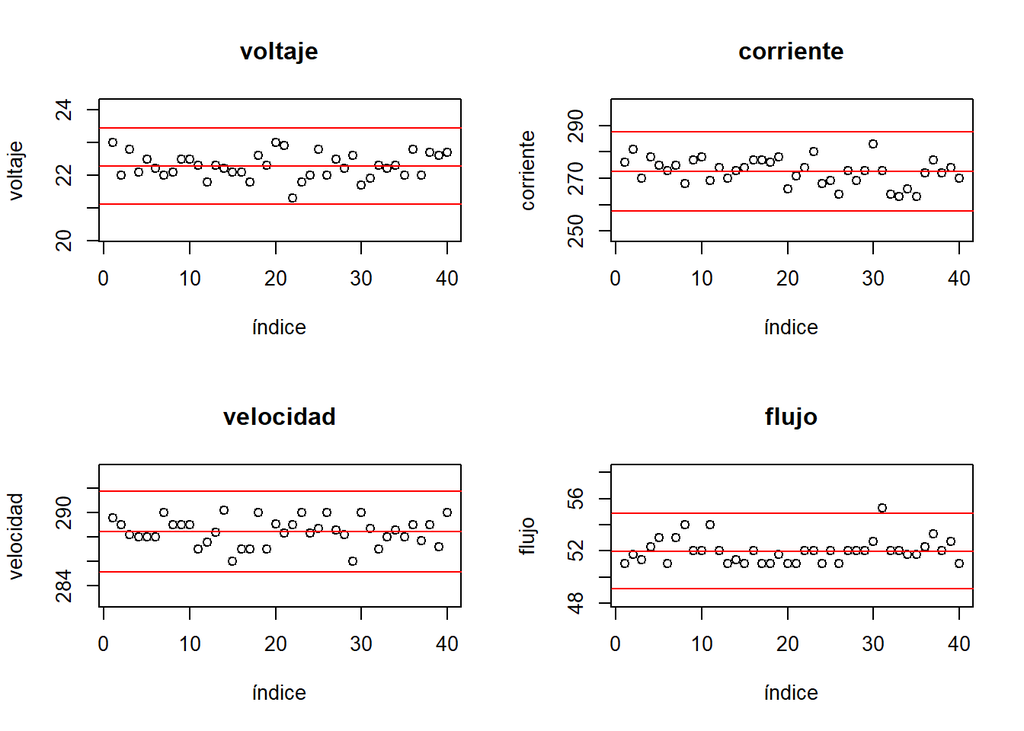

```r
# Construcción de la gráfica de control
# Para cada una de las variables se crea la gráfica de los puntos con la media y dos lineas
# Upper control limit (UCL) mean(x) + 3*sd(x)
# Lower control limit (LCL) mean(x) - 3*sd(x)
par(mfrow=c(2,2))
for(i in 1:p){
  plot(Y[,i], main = names(Y)[i], ylim = c(min(Y[,i]), max(Y[,i])) + c(-1,1)*3*sd(Y[,i]),
       xlab = "índice", ylab = names(Y)[i])
  abline(h = mean(Y[,i]) + c(-1,0,1)*3*sd(Y[,i]), col = "red", lwd = 1)
}
```

Hay dos versiones multivariadas de una gráfica de control, que tomé en cuenta las correlaciones entre las diferentes variables:

1. Elipse de control
2. Gráfica $T^2$

La elipse de control es básicamente la que se obtiene con los estimadores máximo-verosímiles de dos variables a la vez:

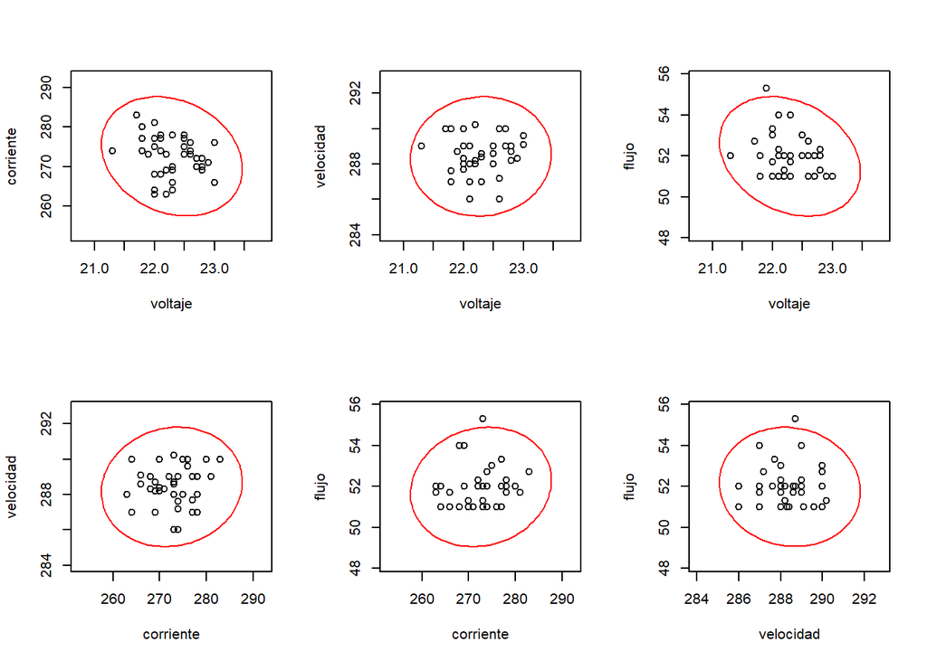

```r
library(ellipse)
indices <- combn(1:p, 2, FUN = list, simplify = T) #lista de combinación de índices
variables <- combn(1:p, 2, FUN = function(x)paste0("Y",x)) #matriz de nombres de la combinación
par(mfrow=c(2,3))
for(i in 1:choose(p,2)){
  ind <- indices[[i]]

  plot(Y[,ind], xlim = mean(Y[,ind[1]]) + c(-4,4) * sd(Y[,ind[1]]),
       ylim = mean(Y[,ind[2]])+c(-4,4)*sd(Y[,ind[2]]))

  lines(ellipse(var(Y[,ind]), centre = colMeans(Y[,ind]),
                level = 0.99), col = "red", type = "l")
}
```

La gráfica $T^2$ calcula para cada observación el valor de la estadística $T^2$ y la compara contra el límite superior UCL

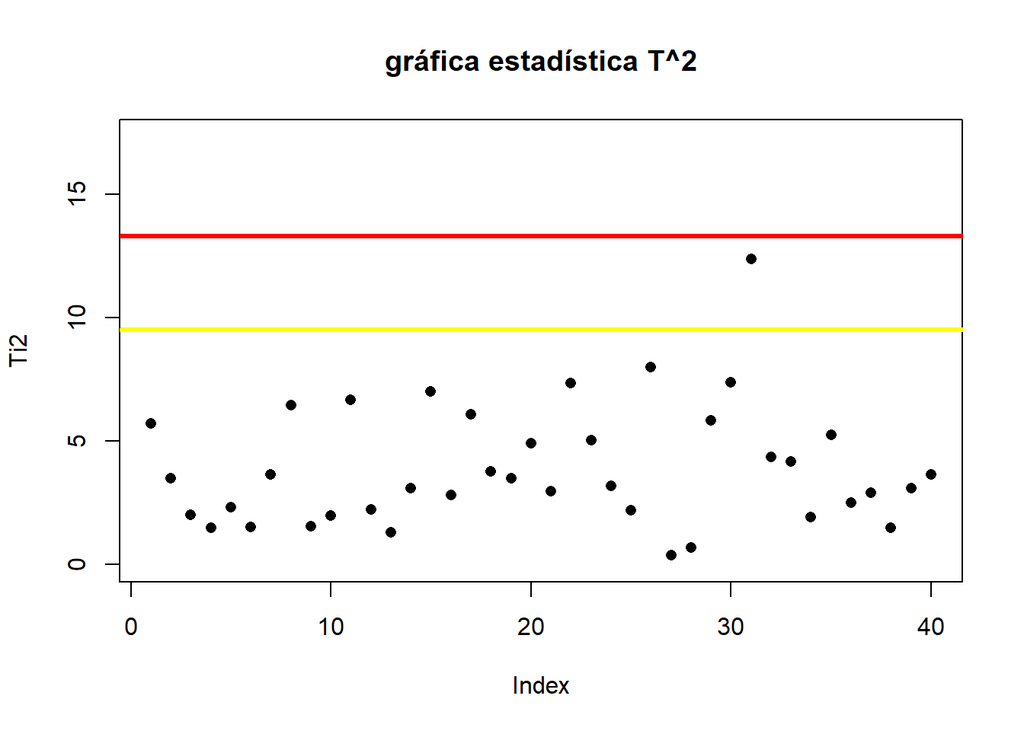

```r
par(mfrow=c(1,1))
Ti2 <- numeric()
for(i in 1:n) Ti2[i] = as.numeric(as.matrix(Y[i,] - colMeans(Y)) %*% solve(var(Y)) %*%
                                          t(Y[i,] - colMeans(Y)))

plot(Ti2, ylim = c(0,1.4*max(Ti2)), pch = 16, main = "gráfica estadística T^2")
abline(h = qchisq(.95,p),col="yellow",lwd=3) #UCL
abline(h = qchisq(.99,p),col="red",lwd=3) #UCL
```